# FinalProjectReport

2022-12-07

# Loading Dataset

```r
df <- read.csv("taxitripdata.csv")
```

# Exploring Dataset

```r
summary(df)
```

```
##     VendorID     tpep_pickup_datetime tpep_dropoff_datetime passenger_count
##  Min.   :1.000   Length:10000         Length:10000          Min.   :0.00
##  1st Qu.:1.000   Class :character     Class :character      1st Qu.:1.00
##  Median :2.000   Mode  :character     Mode  :character      Median :1.00
##  Mean   :1.711                                              Mean   :1.61
##  3rd Qu.:2.000                                              3rd Qu.:2.00
##  Max.   :2.000                                              Max.   :6.00
##  trip_distance      RatecodeID     store_and_fwd_flag  PULocationID
##  Min.   : 0.000   Min.   : 1.000   Length:10000       Min.   :  4
##  1st Qu.: 1.220   1st Qu.: 1.000   Class :character   1st Qu.:107
##  Median : 2.130   Median : 1.000   Mode  :character   Median :148
##  Mean   : 3.207   Mean   : 1.121                      Mean   :155
##  3rd Qu.: 3.900   3rd Qu.: 1.000                      3rd Qu.:232
##  Max.   :42.250   Max.   :99.000                      Max.   :265
##   DOLocationID  payment_type    fare_amount         extra
##  Min.   :  4   Min.   :1.000   Min.   :-80.00   Min.   :-0.500
##  1st Qu.: 88   1st Qu.:1.000   1st Qu.:  7.00   1st Qu.: 0.500
##  Median :151   Median :1.000   Median : 10.00   Median : 0.500
##  Mean   :155   Mean   :1.247   Mean   : 13.04   Mean   : 1.167
##  3rd Qu.:233   3rd Qu.:1.000   3rd Qu.: 15.50   3rd Qu.: 3.000
##  Max.   :265   Max.   :4.000   Max.   :250.00   Max.   : 4.250
##     mta_tax          tip_amount       tolls_amount      improvement_surcharge
##  Min.   :-0.5000   Min.   :  0.000   Min.   :-12.0000   Min.   :-0.3000
##  1st Qu.: 0.5000   1st Qu.:  0.000   1st Qu.:  0.0000   1st Qu.: 0.3000
##  Median : 0.5000   Median :  2.150   Median :  0.0000   Median : 0.3000
##  Mean   : 0.4889   Mean   :  2.503   Mean   :  0.1761   Mean   : 0.2967
##  3rd Qu.: 0.5000   3rd Qu.:  3.360   3rd Qu.:  0.0000   3rd Qu.: 0.3000
##  Max.   : 0.5000   Max.   :100.000   Max.   : 40.0000   Max.   : 0.3000
##   total_amount    congestion_surcharge  airport_fee
##  Min.   :-92.30   Min.   :-2.500       Min.   :-1.250
##  1st Qu.: 12.30   1st Qu.: 2.500       1st Qu.: 0.000
##  Median : 15.96   Median : 2.500       Median : 0.000
##  Mean   : 19.35   Mean   : 2.315       Mean   : 0.045
##  3rd Qu.: 22.30   3rd Qu.: 2.500       3rd Qu.: 0.000
##  Max.   :282.80   Max.   : 2.500       Max.   : 1.250
```

```r
head(df)
```

```
##   VendorID tpep_pickup_datetime tpep_dropoff_datetime passenger_count
## 1        1  2022-01-01 00:35:40   2022-01-01 00:53:29               2
## 2        1  2022-01-01 00:33:43   2022-01-01 00:42:07               1
## 3        2  2022-01-01 00:53:21   2022-01-01 01:02:19               1
## 4        2  2022-01-01 00:25:21   2022-01-01 00:35:23               1
## 5        2  2022-01-01 00:36:48   2022-01-01 01:14:20               1
## 6        1  2022-01-01 00:40:15   2022-01-01 01:09:48               1
##   trip_distance RatecodeID store_and_fwd_flag PULocationID DOLocationID
## 1          3.80          1                  N          142          236
## 2          2.10          1                  N          236           42
## 3          0.97          1                  N          166          166
## 4          1.09          1                  N          114           68
## 5          4.30          1                  N           68          163
## 6         10.30          1                  N          138          161
##   payment_type fare_amount extra mta_tax tip_amount tolls_amount
## 1            1        14.5   3.0     0.5       3.65         0.00
## 2            1         8.0   0.5     0.5       4.00         0.00
## 3            1         7.5   0.5     0.5       1.76         0.00
## 4            2         8.0   0.5     0.5       0.00         0.00
## 5            1        23.5   0.5     0.5       3.00         0.00
## 6            1        33.0   3.0     0.5      13.00         6.55
##   improvement_surcharge total_amount congestion_surcharge airport_fee
## 1                   0.3        21.95                  2.5           0
## 2                   0.3        13.30                  0.0           0
## 3                   0.3        10.56                  0.0           0
## 4                   0.3        11.80                  2.5           0
## 5                   0.3        30.30                  2.5           0
## 6                   0.3        56.35                  2.5           0
```

Creating new column to describe exact time taken for a trip since pickup and dropoff are in datetime format  
Keep in mind the column being added, timeTaken, has units of minutes

```r
df$timeTaken <- paste(difftime(df$tpep_dropoff_datetime,df$tpep_pickup_datetime, units="mins"))
df$timeTaken <- as.numeric(df$timeTaken)
head(df)
```

```
##   VendorID tpep_pickup_datetime tpep_dropoff_datetime passenger_count
## 1        1  2022-01-01 00:35:40   2022-01-01 00:53:29               2
## 2        1  2022-01-01 00:33:43   2022-01-01 00:42:07               1
## 3        2  2022-01-01 00:53:21   2022-01-01 01:02:19               1
## 4        2  2022-01-01 00:25:21   2022-01-01 00:35:23               1
## 5        2  2022-01-01 00:36:48   2022-01-01 01:14:20               1
## 6        1  2022-01-01 00:40:15   2022-01-01 01:09:48               1
##   trip_distance RatecodeID store_and_fwd_flag PULocationID DOLocationID
## 1          3.80          1                  N          142          236
## 2          2.10          1                  N          236           42
## 3          0.97          1                  N          166          166
## 4          1.09          1                  N          114           68
## 5          4.30          1                  N           68          163
## 6         10.30          1                  N          138          161
##   payment_type fare_amount extra mta_tax tip_amount tolls_amount
## 1            1        14.5   3.0     0.5       3.65         0.00
## 2            1         8.0   0.5     0.5       4.00         0.00
## 3            1         7.5   0.5     0.5       1.76         0.00
## 4            2         8.0   0.5     0.5       0.00         0.00
## 5            1        23.5   0.5     0.5       3.00         0.00
## 6            1        33.0   3.0     0.5      13.00         6.55
##   improvement_surcharge total_amount congestion_surcharge airport_fee timeTaken
## 1                   0.3        21.95                  2.5           0 17.816667
## 2                   0.3        13.30                  0.0           0  8.400000
## 3                   0.3        10.56                  0.0           0  8.966667
## 4                   0.3        11.80                  2.5           0 10.033333
## 5                   0.3        30.30                  2.5           0 37.533333
## 6                   0.3        56.35                  2.5           0 29.550000
```

We will be dropping some columns as they are all IDs and will not help in the model since they are categorical variables

```r
new_df <- df %>% select(-c(store_and_fwd_flag, tpep_pickup_datetime, tpep_dropoff_datetime, PULocationID, DOLocationID, VendorID, RatecodeID, payment_type))
```

# Outlier Handling

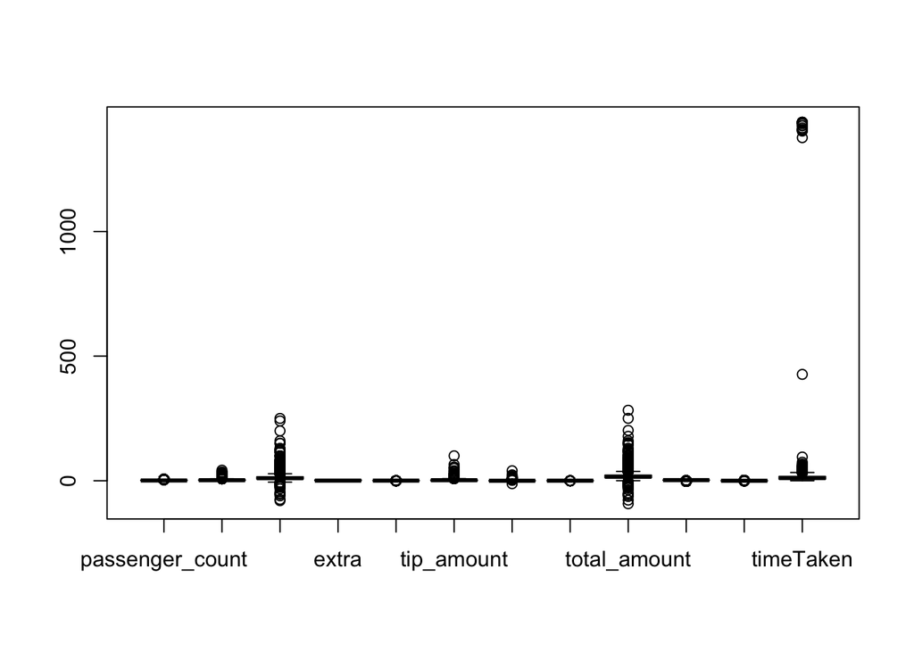

```r
boxplot(new_df)
```

We have now plotted our dataset, so we will remove our outliers first and then choose our sample size  
With the boxplot we can see which variables have outliers and now we will remove them all

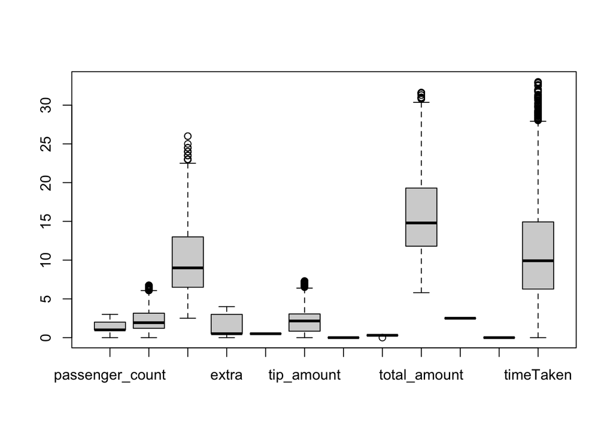

```r
new_df <- new_df[-which(new_df$timeTaken %in% boxplot.stats(new_df$timeTaken)$out), ]
new_df <- new_df[-which(new_df$fare_amount %in% boxplot.stats(new_df$fare_amount)$out), ]
new_df <- new_df[-which(new_df$trip_distance %in% boxplot.stats(new_df$trip_distance)$out), ]
new_df <- new_df[-which(new_df$total_amount %in% boxplot.stats(new_df$total_amount)$out), ]
new_df <- new_df[-which(new_df$tolls_amount %in% boxplot.stats(new_df$tolls_amount)$out), ]
new_df <- new_df[-which(new_df$passenger_count %in% boxplot.stats(new_df$passenger_count)$out), ]
new_df <- new_df[-which(new_df$mta_tax %in% boxplot.stats(new_df$mta_tax)$out), ]
new_df <- new_df[-which(new_df$tip_amount %in% boxplot.stats(new_df$tip_amount)$out), ]
new_df <- new_df[-which(new_df$airport_fee %in% boxplot.stats(new_df$airport_fee)$out), ]
new_df <- new_df[-which(new_df$congestion_surcharge %in% boxplot.stats(new_df$congestion_surcharge)$out), ]

boxplot(new_df)
```

We can see from this that the majority of outliers have been removed, now we can go ahead with our investigation

## Choosing first 500 rows

```r
complete_df <- head(new_df, 500)

summary(complete_df)
```

```
##  passenger_count trip_distance    fare_amount        extra          mta_tax
##  Min.   :0.0     Min.   :0.000   Min.   : 2.50   Min.   :0.000   Min.   :0.5
##  1st Qu.:1.0     1st Qu.:1.137   1st Qu.: 6.50   1st Qu.:0.500   1st Qu.:0.5
##  Median :1.0     Median :1.915   Median : 9.50   Median :0.500   Median :0.5
##  Mean   :1.4     Mean   :2.268   Mean   :10.23   Mean   :1.341   Mean   :0.5
##  3rd Qu.:2.0     3rd Qu.:3.107   3rd Qu.:14.00   3rd Qu.:3.000   3rd Qu.:0.5
##  Max.   :3.0     Max.   :6.400   Max.   :24.50   Max.   :3.000   Max.   :0.5
##    tip_amount     tolls_amount improvement_surcharge  total_amount
##  Min.   :0.000   Min.   :0     Min.   :0.3           Min.   : 6.30
##  1st Qu.:0.000   1st Qu.:0     1st Qu.:0.3           1st Qu.:11.76
##  Median :2.000   Median :0     Median :0.3           Median :15.05
##  Mean   :1.926   Mean   :0     Mean   :0.3           Mean   :15.95
##  3rd Qu.:2.960   3rd Qu.:0     3rd Qu.:0.3           3rd Qu.:19.86
##  Max.   :6.990   Max.   :0     Max.   :0.3           Max.   :31.55
##  congestion_surcharge  airport_fee   timeTaken
##  Min.   :2.5          Min.   :0    Min.   : 0.100
##  1st Qu.:2.5          1st Qu.:0    1st Qu.: 6.046
##  Median :2.5          Median :0    Median :10.108
##  Mean   :2.5          Mean   :0    Mean   :11.257
##  3rd Qu.:2.5          3rd Qu.:0    3rd Qu.:15.150
##  Max.   :2.5          Max.   :0    Max.   :33.000
```

```r
attach(complete_df)
```

# Scatter Plot

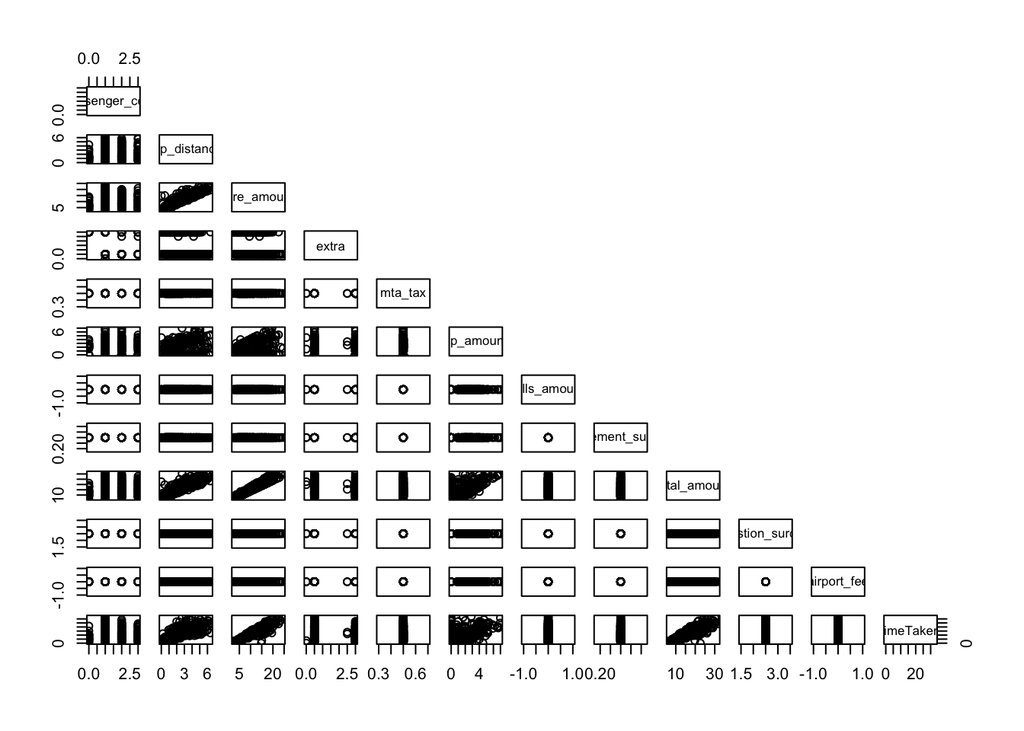

```r
pairs(complete_df, upper.panel=NULL)
```

This output shows:  
Some linear relationship between trip distance and time taken  
No Linear relationship between passenger count and time taken, airport fee and time taken, congestion surhcarge and time taken, improvement surcharge and time taken, tolls amount and time taken, mta tax and time taken, extra and time taken  
Some Linear relationship between tip amount and time taken, but with some noise  
Strong Linear relationship between total amount and time taken, fare amount and time taken

We can also get a closer look at the ones we think is linear from the initial plot

#### trip distance and time taken

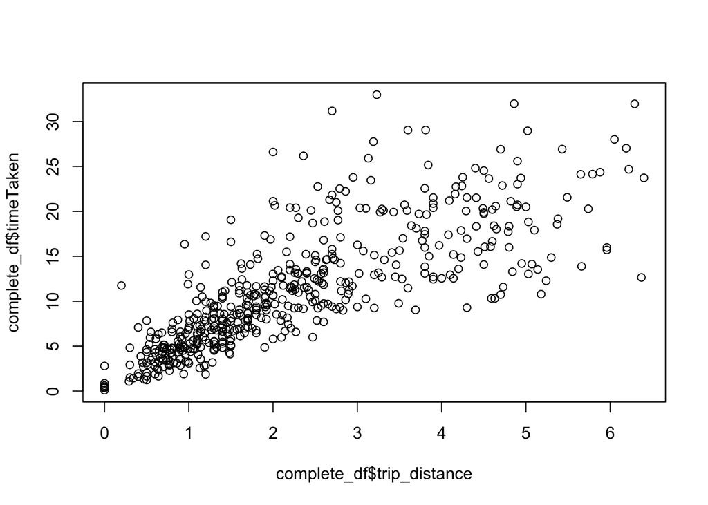

```r
plot(complete_df$trip_distance, complete_df$timeTaken)
```

We can confirm that is relationship is linear

#### total amount and time taken

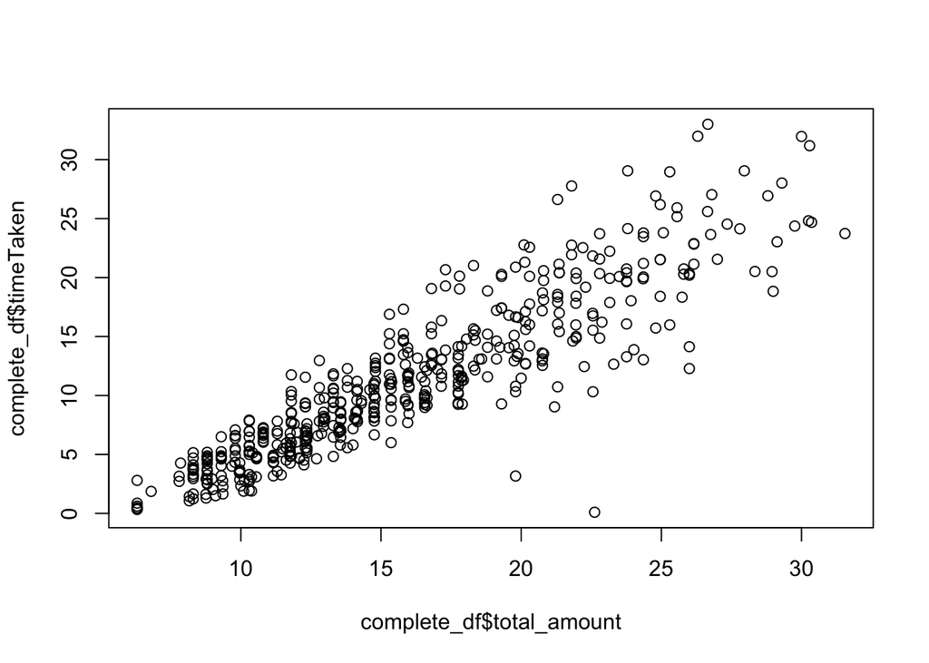

```r
plot(complete_df$total_amount, complete_df$timeTaken)
```

We can confirm that this is also linear

#### fare amount and time taken

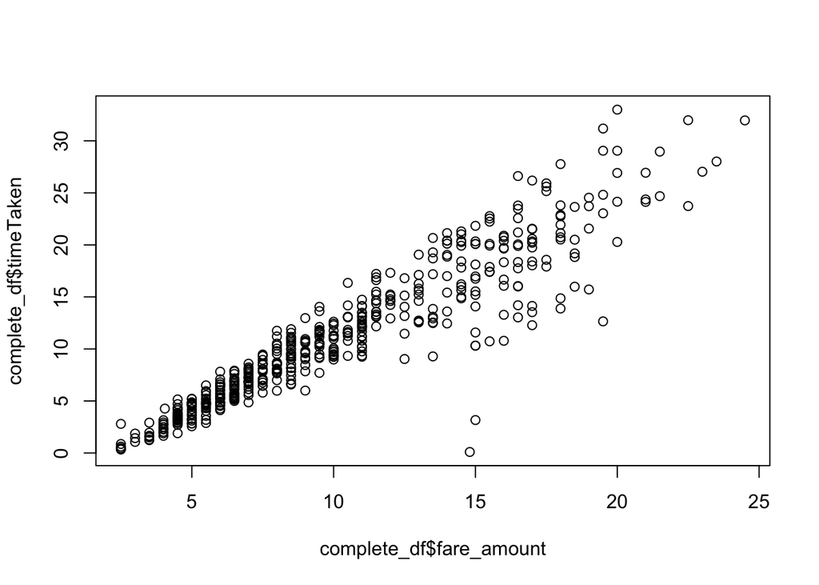

```r
plot(complete_df$fare_amount, complete_df$timeTaken)
```

We can see that there is a strong linear relationship

#### tip amount and time taken

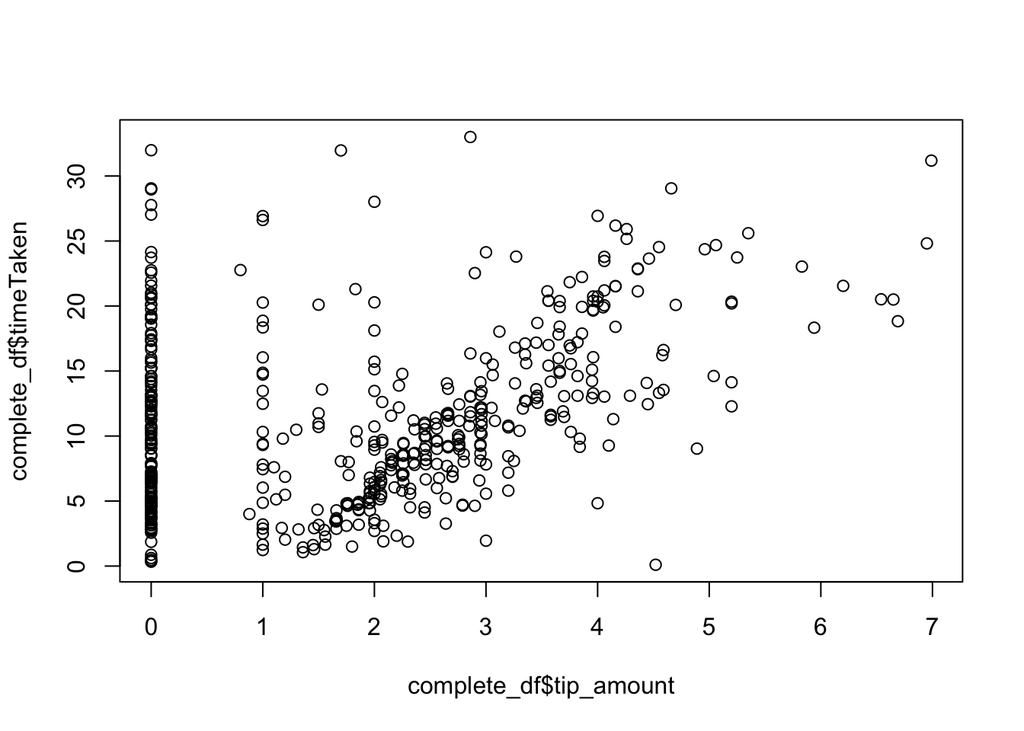

```r
plot(complete_df$tip_amount, complete_df$timeTaken)
```

We can see that there is a very slight linear relationship while there is a lot of noise

# Testing

## Simple Linear Regression

### Trip Distance to Time Taken Linear Regression

#### Model

Now we will create the linear model and then print out a summary to check the R-squared and p-value to check the goodness of this model

```r
lmdistance <- lm(timeTaken~trip_distance, data=complete_df)
summary(lmdistance)
```

```
##
## Call:
## lm(formula = timeTaken ~ trip_distance, data = complete_df)
##
## Residuals:
##      Min       1Q   Median       3Q      Max
## -13.3254  -2.4386  -0.5935   1.7038  18.3781
##
## Coefficients:
##               Estimate Std. Error t value Pr(>|t|)
## (Intercept)     3.1159     0.3432   9.079   <2e-16 ***
## trip_distance   3.5886     0.1274  28.157   <2e-16 ***
## ---
## Signif. codes:  0 '***' 0.001 '**' 0.01 '*' 0.05 '.' 0.1 ' ' 1
##
## Residual standard error: 4.135 on 498 degrees of freedom
## Multiple R-squared:  0.6142, Adjusted R-squared:  0.6134
## F-statistic: 792.8 on 1 and 498 DF,  p-value: < 2.2e-16
```

We can see that:  
p-value is < 0.05, therefore, it shows that the variable is significant  
slope and intercept p-value is < 0.05, therefore, it is clear both coefficients is significant  
this model with distance as predictor explains about 61.3% variability of the target  
residual standard error is 4.135

### Total Amount to Time Taken Linear Regression

#### Model

```r
lmamount <- lm(timeTaken~total_amount, data=complete_df)
summary(lmamount)
```

```
##
## Call:
## lm(formula = timeTaken ~ total_amount, data = complete_df)
##
## Residuals:
##      Min       1Q   Median       3Q      Max
## -18.3891  -1.7151  -0.0756   1.3945  10.1671
##
## Coefficients:
##              Estimate Std. Error t value Pr(>|t|)
## (Intercept)  -6.05121    0.40274  -15.03   <2e-16 ***
## total_amount  1.08490    0.02387   45.45   <2e-16 ***
## ---
## Signif. codes:  0 '***' 0.001 '**' 0.01 '*' 0.05 '.' 0.1 ' ' 1
##
## Residual standard error: 2.934 on 498 degrees of freedom
## Multiple R-squared:  0.8058, Adjusted R-squared:  0.8054
## F-statistic:  2066 on 1 and 498 DF,  p-value: < 2.2e-16
```

We can see that:  
p-value is < 0.05, therefore, it shows that the variable is significant  
slope and intercept p-value is < 0.05, therefore, it is clear both coefficients is significant  
this model with total amount as predictor explains about 80% variability of the target  
residual standard error is 2.934

### Fare Amount to Time Taken Simple Linear Regression

#### Model

```r
lmfare <- lm(timeTaken~fare_amount, data=complete_df)
summary(lmfare)
```

```
##
## Call:
## lm(formula = timeTaken ~ fare_amount, data = complete_df)
##
## Residuals:
##      Min       1Q   Median       3Q      Max
## -17.1488  -0.8847   0.0628   1.1911   8.9304
##
## Coefficients:
##             Estimate Std. Error t value Pr(>|t|)
## (Intercept) -2.16428    0.26432  -8.188 2.25e-15 ***
## fare_amount  1.31169    0.02347  55.883  < 2e-16 ***
## ---
## Signif. codes:  0 '***' 0.001 '**' 0.01 '*' 0.05 '.' 0.1 ' ' 1
##
## Residual standard error: 2.469 on 498 degrees of freedom
## Multiple R-squared:  0.8625, Adjusted R-squared:  0.8622
## F-statistic:  3123 on 1 and 498 DF,  p-value: < 2.2e-16
```

We can see that:  
p-value is < 0.05, therefore, it shows that the variable is significant  
slope and intercept p-value is < 0.05, therefore, it is clear both coefficients is significant  
this model with fare amount as predictor explains about 86% variability of the target  
residual standard error is 2.469

### Tip Amount to Time Taken Simple Linear Regression

#### Model

```r
lmtip <- lm(timeTaken~tip_amount, data=complete_df)
summary(lmtip)
```

```
##
## Call:
## lm(formula = timeTaken ~ tip_amount, data = complete_df)
##
## Residuals:
##     Min      1Q  Median      3Q     Max
## -14.887  -4.487  -1.482   3.776  23.496
##
## Coefficients:
##             Estimate Std. Error t value Pr(>|t|)
## (Intercept)   8.4876     0.4343  19.541  < 2e-16 ***
## tip_amount    1.4379     0.1729   8.317 8.66e-16 ***
## ---
## Signif. codes:  0 '***' 0.001 '**' 0.01 '*' 0.05 '.' 0.1 ' ' 1
##
## Residual standard error: 6.238 on 498 degrees of freedom
## Multiple R-squared:  0.122,  Adjusted R-squared:  0.1202
## F-statistic: 69.18 on 1 and 498 DF,  p-value: 8.659e-16
```

From the Simple Linear Regressions that we ran above, we can say the fare amount gave us the best variability so we will plot the scatterplot along with the regression line

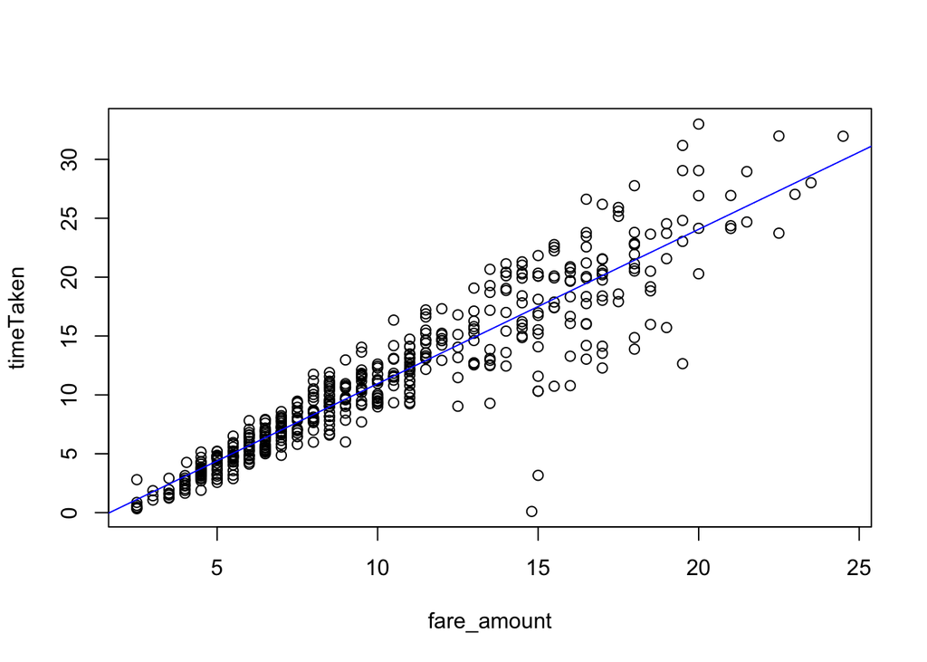

```r
plot(fare_amount, timeTaken)

abline(lmfare, col="blue")
```

As you can see the line does not fully explain the variability within time taken, so maybe we could try multiple linear regression and see if more predictors help improve the line

### Correlation

```r
res <- cor.test(timeTaken, tip_amount)
res
```

```
##
##  Pearson's product-moment correlation
##
## data:  timeTaken and tip_amount
## t = 8.3175, df = 498, p-value = 8.659e-16
## alternative hypothesis: true correlation is not equal to 0
## 95 percent confidence interval:
##  0.2698182 0.4239523
## sample estimates:
##       cor
## 0.3492454
```

correlation is 0.349, since the correlation is not high we can say that this won’t create a lot of noise

```r
res <- cor.test(timeTaken, trip_distance)
res
```

```
##
##  Pearson's product-moment correlation
##
## data:  timeTaken and trip_distance
## t = 28.157, df = 498, p-value < 2.2e-16
## alternative hypothesis: true correlation is not equal to 0
## 95 percent confidence interval:
##  0.7473805 0.8153639
## sample estimates:
##       cor
## 0.7837082
```

correlation of 0.783 means this variable could cause a lot of noise

```r
res <- cor.test(timeTaken, fare_amount)
res
```

```
##
##  Pearson's product-moment correlation
##
## data:  timeTaken and fare_amount
## t = 55.883, df = 498, p-value < 2.2e-16
## alternative hypothesis: true correlation is not equal to 0
## 95 percent confidence interval:
##  0.9155617 0.9398434
## sample estimates:
##       cor
## 0.9286913
```

We get a correlation of 0.929 so we can say it can cause a lot of noise as well

```r
res <- cor.test(timeTaken, total_amount)
res
```

```
##
##  Pearson's product-moment correlation
##
## data:  timeTaken and total_amount
## t = 45.455, df = 498, p-value < 2.2e-16
## alternative hypothesis: true correlation is not equal to 0
## 95 percent confidence interval:
##  0.8791683 0.9134426
## sample estimates:
##       cor
## 0.8976544
```

The correlation for this is 0.898 so it will have a lot of noise when added to the model

After running the correlation tests, we can see what correlation we get, while some are high this could cause noise in our MLR model or it could help make it more accurate

### Check for Multi-Colinearity

```r
res <- cor.test(fare_amount, tip_amount)
res
```

```
##
##  Pearson's product-moment correlation
##
## data:  fare_amount and tip_amount
## t = 8.7097, df = 498, p-value < 2.2e-16
## alternative hypothesis: true correlation is not equal to 0
## 95 percent confidence interval:
##  0.2849755 0.4373278
## sample estimates:
##       cor
## 0.3635804
```

We get a correlation of 0.363 therefore it should not have a lot of noise when added together

```r
res <- cor.test(fare_amount, total_amount)
res
```

```
##
##  Pearson's product-moment correlation
##
## data:  fare_amount and total_amount
## t = 78.562, df = 498, p-value < 2.2e-16
## alternative hypothesis: true correlation is not equal to 0
## 95 percent confidence interval:
##  0.9547941 0.9679824
## sample estimates:
##       cor
## 0.9619445
```

We get a correlation of 0.962 therefore this could create a lot of noise when added together in the model

```r
res <- cor.test(fare_amount, trip_distance)
res
```

```
##
##  Pearson's product-moment correlation
##
## data:  fare_amount and trip_distance
## t = 55.617, df = 498, p-value < 2.2e-16
## alternative hypothesis: true correlation is not equal to 0
## 95 percent confidence interval:
##  0.9148398 0.9393224
## sample estimates:
##       cor
## 0.9280773
```

We get a correlation of 0.928 therefore this could create a lot of noise when added together in the model

```r
res <- cor.test(total_amount, tip_amount)
res
```

```
##
##  Pearson's product-moment correlation
##
## data:  total_amount and tip_amount
## t = 16.92, df = 498, p-value < 2.2e-16
## alternative hypothesis: true correlation is not equal to 0
## 95 percent confidence interval:
##  0.5453818 0.6570570
## sample estimates:
##       cor
## 0.6041777
```

We get a correlation of 0.604 therefore this could create noise as well within our model

```r
res <- cor.test(total_amount, trip_distance)
res
```

```
##
##  Pearson's product-moment correlation
##
## data:  total_amount and trip_distance
## t = 43.567, df = 498, p-value < 2.2e-16
## alternative hypothesis: true correlation is not equal to 0
## 95 percent confidence interval:
##  0.8702635 0.9069386
## sample estimates:
##       cor
## 0.8900323
```

We get a correlation of 0.890 therefore this could create a lot of noise as well within our model

```r
res <- cor.test(trip_distance, tip_amount)
res
```

```
##
##  Pearson's product-moment correlation
##
## data:  trip_distance and tip_amount
## t = 7.6869, df = 498, p-value = 8.094e-14
## alternative hypothesis: true correlation is not equal to 0
## 95 percent confidence interval:
##  0.2449859 0.4018929
## sample estimates:
##     cor
## 0.32568
```

We get a correlation of 0.326 therefore there is less chances of this creating noise in our model

We can see that some of the correlation values are high which could mean when added to a multiple linear regression model it could add a lot of noise, however, it could also not add noise but rather help the significance of the model instead

## Multiple Linear Regression

Now that we have created our linear regression models, cleaned our data, and identified which variables are significant and have linear relationship with the time taken  
We will create the multiple regression model by adding different variables and seeing how the p-value is affected so that we create a model with the least p-value and a good r-squared value as well

### Fare Amount + Total Amount

#### Model

```r
lm_fare_total = lm(timeTaken~fare_amount+ total_amount, data=complete_df)
summary(lm_fare_total)
```

```
##
## Call:
## lm(formula = timeTaken ~ fare_amount + total_amount, data = complete_df)
##
## Residuals:
##      Min       1Q   Median       3Q      Max
## -17.2555  -0.9040   0.0361   1.1794   8.9496
##
## Coefficients:
##              Estimate Std. Error t value Pr(>|t|)
## (Intercept)  -2.47447    0.42066  -5.882 7.44e-09 ***
## fare_amount   1.23335    0.08591  14.356  < 2e-16 ***
## total_amount  0.06969    0.07351   0.948    0.344
## ---
## Signif. codes:  0 '***' 0.001 '**' 0.01 '*' 0.05 '.' 0.1 ' ' 1
##
## Residual standard error: 2.469 on 497 degrees of freedom
## Multiple R-squared:  0.8627, Adjusted R-squared:  0.8622
## F-statistic:  1562 on 2 and 497 DF,  p-value: < 2.2e-16
```

### Fare Amount + Trip Distance

#### Model

```r
lm_fare_trip = lm(timeTaken~fare_amount+trip_distance, data=complete_df)
summary(lm_fare_trip)
```

```
##
## Call:
## lm(formula = timeTaken ~ fare_amount + trip_distance, data = complete_df)
##
## Residuals:
##      Min       1Q   Median       3Q      Max
## -26.3820  -0.4726   0.0738   0.7746   6.2319
##
## Coefficients:
##               Estimate Std. Error t value Pr(>|t|)
## (Intercept)   -3.86969    0.24489  -15.80   <2e-16 ***
## fare_amount    2.05079    0.05201   39.43   <2e-16 ***
## trip_distance -2.58184    0.16861  -15.31   <2e-16 ***
## ---
## Signif. codes:  0 '***' 0.001 '**' 0.01 '*' 0.05 '.' 0.1 ' ' 1
##
## Residual standard error: 2.037 on 497 degrees of freedom
## Multiple R-squared:  0.9066, Adjusted R-squared:  0.9062
## F-statistic:  2411 on 2 and 497 DF,  p-value: < 2.2e-16
```

p-value < 0.05, therefore, the model is significant  
p-value for all the coefficients is < 0.05, meaning that the slope and intercept coefficients are statistically significant  
This model with fare amount and trip distance explains about 90.6% variability of time taken  
residual standard error is 2.037  
this is model is showing us good results, maybe we could try adding another variable to the model and see how it responds

#### Anova

Now we must test whether the improvement in variability in Adjusted R squared is significant or not  
We can test this by using ANOVA, having a null hypothesis as improvement in adjusted r squared is not statistically significant, and the alternative hypothesis is the improvement in adjusted r squared is statistically significant

```r
anova(lmfare, lm_fare_trip)
```

```
## Analysis of Variance Table
##
## Model 1: timeTaken ~ fare_amount
## Model 2: timeTaken ~ fare_amount + trip_distance
##   Res.Df    RSS Df Sum of Sq      F    Pr(>F)
## 1    498 3035.6
## 2    497 2062.5  1    973.06 234.47 < 2.2e-16 ***
## ---
## Signif. codes:  0 '***' 0.001 '**' 0.01 '*' 0.05 '.' 0.1 ' ' 1
```

the p-value from the anova shows us that we can reject the null hypothesis and accept the alternative hypothesis  
so the improvement for the adjusted r squared is statistically significant

### Fare Amount + Trip Distance + Tip Amount

#### Model

```r
lm_fare_trip_tip = lm(timeTaken~fare_amount+trip_distance+tip_amount, data=complete_df)
summary(lm_fare_trip_tip)
```

```
##
## Call:
## lm(formula = timeTaken ~ fare_amount + trip_distance + tip_amount,
##     data = complete_df)
##
## Residuals:
##      Min       1Q   Median       3Q      Max
## -26.4218  -0.4769   0.0659   0.7752   6.1713
##
## Coefficients:
##               Estimate Std. Error t value Pr(>|t|)
## (Intercept)   -3.88355    0.24768 -15.680   <2e-16 ***
## fare_amount    2.04721    0.05286  38.729   <2e-16 ***
## trip_distance -2.57961    0.16885 -15.278   <2e-16 ***
## tip_amount     0.02359    0.06069   0.389    0.698
## ---
## Signif. codes:  0 '***' 0.001 '**' 0.01 '*' 0.05 '.' 0.1 ' ' 1
##
## Residual standard error: 2.039 on 496 degrees of freedom
## Multiple R-squared:  0.9066, Adjusted R-squared:  0.906
## F-statistic:  1604 on 3 and 496 DF,  p-value: < 2.2e-16
```

### Fare Amount + Trip Distance + Total Amount

#### Model

```r
lm_fare_trip_total = lm(timeTaken~fare_amount+trip_distance+total_amount, data=complete_df)
summary(lm_fare_trip_total)
```

```
##
## Call:
## lm(formula = timeTaken ~ fare_amount + trip_distance + total_amount,
##     data = complete_df)
##
## Residuals:
##      Min       1Q   Median       3Q      Max
## -26.4387  -0.4849   0.0778   0.7934   6.1168
##
## Coefficients:
##               Estimate Std. Error t value Pr(>|t|)
## (Intercept)   -4.06705    0.36252 -11.219   <2e-16 ***
## fare_amount    1.99943    0.08684  23.023   <2e-16 ***
## trip_distance -2.57850    0.16875 -15.280   <2e-16 ***
## total_amount   0.04483    0.06070   0.739     0.46
## ---
## Signif. codes:  0 '***' 0.001 '**' 0.01 '*' 0.05 '.' 0.1 ' ' 1
##
## Residual standard error: 2.038 on 496 degrees of freedom
## Multiple R-squared:  0.9067, Adjusted R-squared:  0.9061
## F-statistic:  1606 on 3 and 496 DF,  p-value: < 2.2e-16
```

### Residual Plot

#### Checking Linearity Assumption

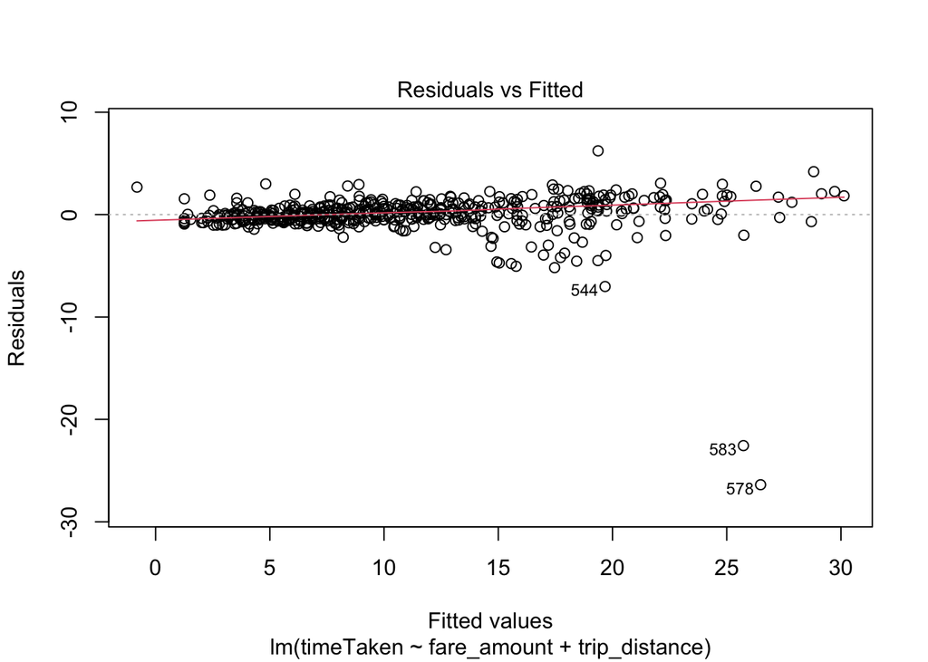

```r
plot(lm_fare_trip, 1)
```

The red line is pretty much horizontal indicating that the linearity assumption holds well  
Residual fluctuates between the -7 to 7 bound, which shows the fitted model is good prediction to a certain extent  
Since we have a few points outside the bounds, 544, 583, 578, these could be outliers since they are very far from the 0 line  
Large residuals tell us that there could indicate that either the variance is not constant (heterosceadasticity) or the true relationship between the variables is non linear  
While there is a slight variance we could try transforming the data and see if the model is improved

#### Transforming using log(n)

Here we try transforming to try and get a better variance

```r
new_df <- complete_df
new_df$timeTaken <- log(new_df$timeTaken)
new_df <- new_df[is.finite(rowSums(new_df)),]

lm_fare_trip_transf <- lm(timeTaken~fare_amount+trip_distance, data=new_df)
summary(lm_fare_trip_transf)
```

```
##
## Call:
## lm(formula = timeTaken ~ fare_amount + trip_distance, data = new_df)
##
## Residuals:
##     Min      1Q  Median      3Q     Max
## -5.4014 -0.0916  0.0837  0.2235  0.4971
##
## Coefficients:
##               Estimate Std. Error t value Pr(>|t|)
## (Intercept)    0.82361    0.05069  16.248   <2e-16 ***
## fare_amount    0.15373    0.01077  14.280   <2e-16 ***
## trip_distance -0.08416    0.03490  -2.411   0.0163 *
## ---
## Signif. codes:  0 '***' 0.001 '**' 0.01 '*' 0.05 '.' 0.1 ' ' 1
##
## Residual standard error: 0.4217 on 497 degrees of freedom
## Multiple R-squared:  0.679,  Adjusted R-squared:  0.6778
## F-statistic: 525.8 on 2 and 497 DF,  p-value: < 2.2e-16
```

As you can see the transformation has not helped the model at all, in fact it has made our model worse with an 67.7% variability now while before we had a 90.6% variability  
Therefore, we will choose not to transform it as our previous model before transforming seems to be more significant